# 머신러닝 (Machine Learning)

## 머신러닝 방식

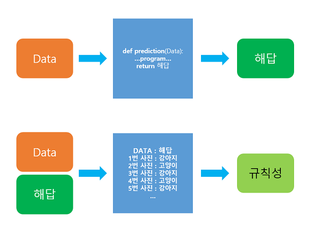

- 위쪽은 기존의 프로그래밍의 접근 방식, 아래쪽은 머신러닝의 접근 방식
- **머신 러닝은 데이터가 주어지면, 기계가 스스로 데이터로부터 규칙성을 찾는 것에 집중**
  - 주어진 데이터로부터 규칙성을 찾는 과정을 훈련(training) 또는 학습(learning)
- 일단 규칙성을 발견하고나면, 그 후에 들어오는 새로운 데이터에 대해서 발견한 규칙성을 기준으로 정답을 찾아냄

## 머신러닝 흝어보기

### 머신러닝 모델의 평가

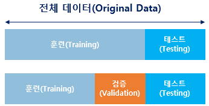

- 데이터를 준비했다면 기계를 학습하기 전 해당 데이터를 **훈련용, 검증용, 테스트용** 세 가지로 분리하는 것이 일반적
- **훈련 데이터** : 머신 러닝 모델을 학습하는 용도
- **테스트 데이터** : 학습한 머신 러닝 모델의 성능을 평가하기 위한 용도
- **검증용 데이터** : 모델의 성능을 조정하기 위한 용도. **더 정확히는 모델이 훈련 데이터에 과적합(overfitting) 이 되고 있는지 판단하거나 하이퍼파라미터의 조정을 위한 용도**
  - **하이퍼파라미터(초매개변수)** : 모델의 성능에 영향을 주는 **사람이 값을 지정**하는 변수.
  - **매개변수** : 가중치와 편향. 학습을 하는 동안 값이 계속해서 변하는 수.
- 가중치와 편향과 같은 매개변수는 사용자가 결정해주는 값이 아니라 **모델이 학습하는 과정에서 얻어지는 값**
- 훈련용 데이터로 훈련을 모두 시킨 모델은 검증용 데이터를 사용하여 정확도를 검증하며 **하이퍼파라미터를 튜닝(tuning)**

## 분류(Classification)와 회귀(Regression)

### 1) 이진 분류 문제(Binary Classification)

- 이진 분류는 주어진 입력에 대해서 **두 개의 선택지 중 하나의 답을 선택해야 하는 경우**

### 2) 다중 클래스 분류(Multi-class Classification)

- 다중 클래스 분류는 주어진 입력에 대해서 **세 개 이상의 선택지 중에서 답을 선택해야 하는 경우**

### 3) 회귀 문제(Regression)

- 선택지 중에서 정해져 있는 경우가 아니라 어떠한 **연속적인 값의 범위 내에서 예측값이 나오는 경우**

## 지도 학습과 비지도 학습

### 1) 지도 학습(Supervised Learning)

- **지도 학습 : 레이블(Label)이라는 정답과 함께 학습하는 것**
  - 자연어 처리는 대부분 지도 학습에 속함

### 2) 비지도 학습(Unsupervised Learning)

- **비지도 학습 : 데이터에 별도의 레이블이 없이 학습하는 것**
  - e.g 토픽 모델링 알고리즘 LSA나 LDA

## 샘플(Sample)과 특성(Feature)

- **대부분의 머신 러닝 문제가 1개 이상의 독립 변수 $x$를 가지고 종속 변수 $y$를 예측**
- 머신 러닝 모델 중 특히 인공 신경망은 독립 변수, 종속 변수, 가중치, 편향 등을 행렬 연산을 통해 연산하는 경우가 다수

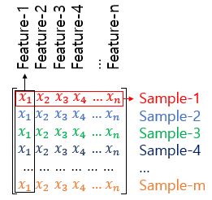

# 혼동 행렬(Confusion Matrix)

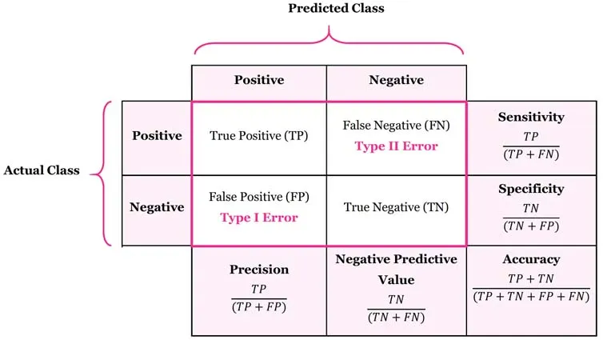

- **True Positive(TP)** : 실제 True인 정답을 True라고 예측 (정답)
- **False Positive(FP)** : 실제 False인 정답을 True라고 예측 (오답)
- **False Negative(FN)** : 실제 True인 정답을 False라고 예측 (오답)
- **True Negative(TN)** : 실제 False인 정답을 False라고 예측 (정답)

### 정밀도(Precision) : 모델이 True라고 분류한 것 중에서 실제 True인 것의 비율

$$정밀도 = {{TP}\over{TP\;+\;FP}}$$

### 재현율(Recall) : 실제 True인 것 중에서 모델이 True라고 예측한 것의 비율

$$재현율 = {{TP}\over{TP\;+\;FN}}$$

### 정확도(Accuracy) :

$$정확도 = {{TP\;+TN}\over{TP\;+\;FN\;+FP\;+TN}}$$

# 과적합(Overfitting)과 과소 적합(Underfitting)

- 머신 러닝 모델이 학습에 사용하는 훈련 데이터는 실제로 앞으로 기계가 풀어야 할 현실의 수많은 문제에 비하면 극히 일부에 불과한 데이터
  - 기계가 훈련 데이터에 대해서만 과하게 학습하면 성능 측정을 위한 데이터인 테스트 데이터나 실제 서비스에서는 정확도가 좋지 않은 현상이 발생

## 과적합

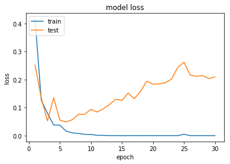

## 과소적합

- 테스트 데이터의 성능이 올라갈 여지가 있음에도 훈련을 덜 한 상태를 과소적합(Underfitting)
- 과소 적합은 훈련 자체가 부족한 상태이므로 훈련 횟수인 에포크가 지나치게 적으면 발생
- **과대 적합과는 달리 과소 적합은 훈련 자체를 너무 적게한 상태이므로 훈련 데이터에 대해서도 정확도가 낮다는 특징이 존재**
- 머신 러닝을 할 때는 과적합을 막을 수 있는 드롭 아웃(Dropout), 조기 종료(Early Stopping)과 같은 방법이 존재
- 현업에서는 테스트 데이터를 두 가지 용도로 분리하여 사용하는 것이 더 바람직
  - 1. 과적합 모니터링 & 하이퍼파라미터 튜닝을 위한 테스트 데이터 : 검증용 데이터
  - 2. 성능 평가만을 위한 테스트 데이터 : 테스트 데이터

### 일반적인 딥 러닝 모델의 학습 과정

**Step 1.** 주어진 데이터를 훈련 데이터, 검증 데이터, 테스트 데이터로 나눈다. 가령, 6:2:2 비율로 나눌 수 있다.

Step 2. 훈련 데이터로 모델을 학습한다. (에포크 +1)

**Step 3**. 검증 데이터로 모델을 평가하여 검증 데이터에 대한 정확도와 오차(loss)를 계산한다.

**Step 4.** 검증 데이터의 오차가 증가하였다면 과적합 징후이므로 학습 종료 후 Step 5로 이동, 아니라면 Step 2.로 재이동한다.

**Step 5.** 모델의 학습이 종료되었으니 테스트 데이터로 모델을 평가한다.